# Using Accelerometer Data to Predict How an Exercise was Done

Vikram Radhakrishnan

## Synopsis

Devices such as Jawbone Up, Nike FuelBand, and Fitbit are equipped with accelerometers which can collect a large amount of data about an individual’s personal activity, recorded during periods of training or exercise, relatively inexpensively. One fairly common use of this data is to quantify how much of a particular activity they do, but they rarely quantify how well they do it. The aim of this project is to predict how well a particular exercise was done, using a vast amount of data obtained from accelerometers on the belt, forearm, arm, and dumbell of 6 participants. The participants asked were to perform barbell lifts correctly and incorrectly in 5 different ways. For more information about this study, please visit: [Human Activity Recognition](http://groupware.les.inf.puc-rio.br/har).

## Data Source

The data for this project were obtained from the following links:

1. Link to [Training Data](https://d396qusza40orc.cloudfront.net/predmachlearn/pml-training.csv).
2. Link to [Test Data](https://d396qusza40orc.cloudfront.net/predmachlearn/pml-testing.csv).

*Note: The goal of this project will be to build a predictor on a fraction of the training data set, which will then be validated on the remaining portion of the training data set. Based on the validation dataset results, a predictor algorithm will be selected to predict the test data set.*

## Procedure

#### Loading Data

*Note: Certain packages are required in order to reproduce the analysis shown here. These are the caret, rpart and rattle packages. PBefore running this analysis, please install packages using the command: install.package(“packagename”)*

```r
library(caret)
library(rpart)
library(rattle)
```

We first check if the data is already downloaded and available to us. If not, we download the csv files and read it into R with the read.csv() function.

```r
if(!file.exists("pml-training.csv")) {
  fileURL <- "https://d396qusza40orc.cloudfront.net/predmachlearn/pml-training.csv"
  download.file(fileURL, destfile = "pml-training.csv", method = "curl")
}

if(!file.exists("pml-testing.csv")) {
  fileURL <- "https://d396qusza40orc.cloudfront.net/predmachlearn/pml-testing.csv"
  download.file(fileURL, destfile = "pml-testing.csv", method = "curl")
}

## Read the csv files into R
training <- read.csv("pml-training.csv", header=TRUE, sep = ",", na.strings = c("","NA"), stringsAsFactors = FALSE)
testing <- read.csv("pml-testing.csv", header=TRUE, sep = ",", na.strings = c("","NA"), stringsAsFactors = FALSE)
```

#### Data Partitioning

The training data set is fairly large - it has over 19000 measurements. So it would be reasonable to use about 75% of the training set to train a predictor on, and then validate the predictor on the remaining 25%. We use the createDataPartition to do the splitting.

```r
set.seed(5390)
inTrain <- createDataPartition(y=training$classe, p=0.75, list=F)
myTrain <- training[inTrain, ]
myValidate <- training[-inTrain, ]
```

#### Cleaning Data

There are 160 variables in the training dataset. Not all of these variables will be useful to us in building a predictor. In order to select only the most useful variables, we will remove all the variables that have near zero variance and that are mostly NAs. From the training data set it is also apparent that not all the data relates to accelerometer measurements. Some of the data are user names and timestamps, etc. Assuming that only the accelerometer measurements should be enough to make predictions, we will therefore also discard the first seven columns of the data.

```r
## Remove the variables that are unnecessary for prediction (First seven in this case).
myTrain <- myTrain[c(-1:-7)]

## Remove Near Zero Variance (NZV) variables.
NZV <- nearZeroVar(myTrain)
myTrain <- myTrain[, -NZV]

## Remove variables that are mostly NAs.
## In this scenario, if a column is more than 80% NA it will be removed
goodCols <- names(myTrain[sapply(myTrain, function(x) mean(sum(is.na(x)))) < 0.2])
myTrain <- myTrain[,goodCols]

## Now do the same for the validation set and test set
## Note that only the NAs and NZVs from the training set are used
myValidate <- myValidate[c(-1:-7)]
myValidate <- myValidate[, -NZV]
myValidate <- myValidate[, goodCols]

testing <- testing[c(-1:-7)]
testing <- testing[, -NZV]
testing <- testing[, goodCols[-53]] # Leaving out the outcome here
```

#### Preprocessing Data

Excluding the classe variable which is the outcome, we have 52 predictors to work with. There could well be some very highly correlated predictors. Here we examine whether there exist such highly correlated predictors in our new dataset.

```r
M <- abs(cor(myTrain[-53]))
diag(M) <- 0 # Ignore self-correlation
which(M > 0.9, arr.ind=T)
```

```
##                  row col
## total_accel_belt   4   1
## accel_belt_y       9   1
## accel_belt_z      10   1
## accel_belt_x       8   2
## roll_belt          1   4
## accel_belt_y       9   4
## accel_belt_z      10   4
## pitch_belt         2   8
## roll_belt          1   9
## total_accel_belt   4   9
## accel_belt_z      10   9
## roll_belt          1  10
## total_accel_belt   4  10
## accel_belt_y       9  10
## gyros_arm_y       19  18
## gyros_arm_x       18  19
## gyros_dumbbell_z  33  31
## gyros_forearm_z   46  31
## gyros_dumbbell_x  31  33
## gyros_forearm_z   46  33
## gyros_dumbbell_x  31  46
## gyros_dumbbell_z  33  46
```

Indeed there are several highly correlated variables. Using Principal Component Analysis (PCA) we can capture most of the variability using some combination of the predictor variables. We will therefore include PCA preprocessing in our model constructor.

#### Building the Model

For our first attempt at building a predictor, we will use a decision tree algorithm.

```r
modelFitTree <- train(classe ~ ., data=myTrain, preProcess="pca", method="rpart")
confusionMatrix(myValidate$classe, predict(modelFitTree,myValidate))
```

```
## Confusion Matrix and Statistics
##
##           Reference
## Prediction    A    B    C    D    E
##          A 1373    0    0    0   22
##          B  844    0    0    0  105
##          C  846    0    0    0    9
##          D  739    0    0    0   65
##          E  600    0    0    0  301
##
## Overall Statistics
##
##                Accuracy : 0.3414
##                  95% CI : (0.3281, 0.3548)
##     No Information Rate : 0.8976
##     P-Value [Acc > NIR] : 1
##
##                   Kappa : 0.0926
##  Mcnemar's Test P-Value : NA
##
## Statistics by Class:
##
##                      Class: A Class: B Class: C Class: D Class: E
## Sensitivity            0.3119       NA       NA       NA  0.59960
## Specificity            0.9562   0.8065   0.8257   0.8361  0.86370
## Pos Pred Value         0.9842       NA       NA       NA  0.33407
## Neg Pred Value         0.1368       NA       NA       NA  0.94979
## Prevalence             0.8976   0.0000   0.0000   0.0000  0.10237
## Detection Rate         0.2800   0.0000   0.0000   0.0000  0.06138
## Detection Prevalence   0.2845   0.1935   0.1743   0.1639  0.18373
## Balanced Accuracy      0.6340       NA       NA       NA  0.73165
```

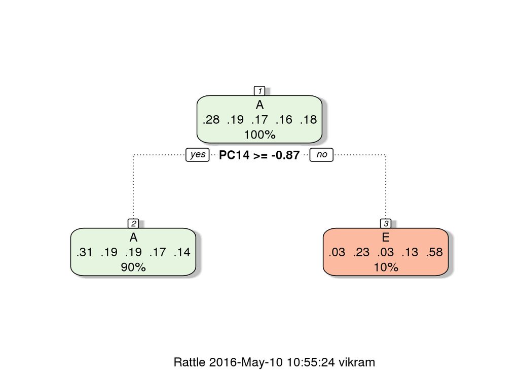

```r
## Display the decision tree
fancyRpartPlot(modelFitTree$finalModel)
```

Random Forest algorithms are far superior to most predictor algorithms in terms of accuracy, which is why they are often used in machine learning competitions. Their downside is the intensive computation power they require. A Random Forest algorithm will average the predictions of several decision trees to come up with a superior prediction. We show here the results of building a predictor with Random Forests.

```r
modelFitRF <- train(classe ~ ., data=myTrain, method="rf")
confusionMatrix(myValidate$classe, predict(modelFitRF,myValidate))
```

```
## Confusion Matrix and Statistics
##
##           Reference
## Prediction    A    B    C    D    E
##          A 1395    0    0    0    0
##          B    5  943    1    0    0
##          C    0    9  844    2    0
##          D    0    0   16  787    1
##          E    0    0    0    1  900
##
## Overall Statistics
##
##                Accuracy : 0.9929
##                  95% CI : (0.9901, 0.995)
##     No Information Rate : 0.2855
##     P-Value [Acc > NIR] : < 2.2e-16
##
##                   Kappa : 0.991
##  Mcnemar's Test P-Value : NA
##
## Statistics by Class:
##
##                      Class: A Class: B Class: C Class: D Class: E
## Sensitivity            0.9964   0.9905   0.9803   0.9962   0.9989
## Specificity            1.0000   0.9985   0.9973   0.9959   0.9998
## Pos Pred Value         1.0000   0.9937   0.9871   0.9789   0.9989
## Neg Pred Value         0.9986   0.9977   0.9958   0.9993   0.9998
## Prevalence             0.2855   0.1941   0.1756   0.1611   0.1837
## Detection Rate         0.2845   0.1923   0.1721   0.1605   0.1835
## Detection Prevalence   0.2845   0.1935   0.1743   0.1639   0.1837
## Balanced Accuracy      0.9982   0.9945   0.9888   0.9960   0.9993
```

As expected, the accuracy of the Random Forest predictor is much better. So we will use this predictor to predict the outcomes for the test set.

```r
solutions <- predict(modelFitRF, testing)
print(solutions)
```

```
##  [1] B A B A A E D B A A B C B A E E A B B B
## Levels: A B C D E
```